# Behavioral Economics Capstone: Memory Group

Donald Dinerman

# Experimental Design

**Industry Partners**

Minnesota Wild & New York Islanders (NHL Teams)

**Research Objective**

Using a behaviorally-informed approach to increase season ticket renewals.

**Behavioral Approach**

*Issue*

The emails sent out to season ticket holders are do not clearly convey the message that they should renew their tickets and the benefits are displayed sloppily in a matrix.

*Solution*

Modify the email format to concisely highlight the main message that season ticket holders should renew their tickets and to better showcase the benefits.

**Variables of Interest**

1. Benefit Memory Retention
2. Season Ticket Renewal Likelihood
3. Demographic Information (e.g., Age, Gender)

**Control**

Current Minnesota Wild email communications to season ticket holders.

[figure not shown]

**Treatments**

All treatments have the same concise messaging regarding season ticket renewals. The differences are how we design the benefits matrix.

1. Ranking: Organize the benefits by their rankings according to subjects’ preferences.

[figure not shown]

2. Categorization: Create buckets relating the benefits while maintaining the ranking system within each bucket.

[figure not shown]

3. Reduced List: Display the 5 highest ranked benefits in a matrix.

[figure not shown]

**Experimental Survey Flow**

We designed our survey on Qualtrics and deployed it using MTurk.

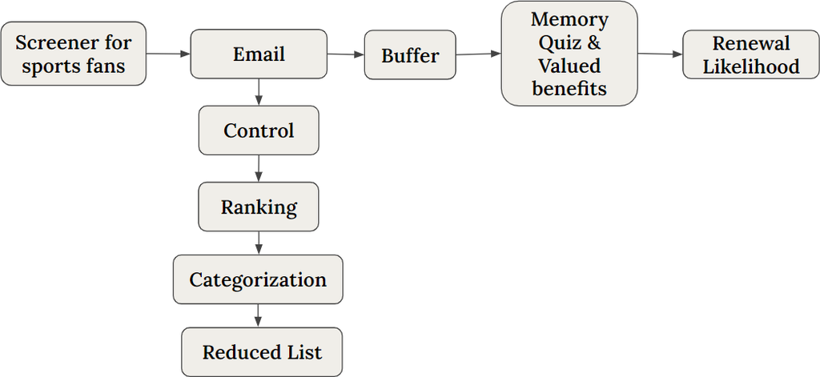

# Pre-Test

Before our experimental survey, we conducted a pre-test survey to learn about our subject pool’s preferences regarding season ticket benefits.

These preferences were then used to inform our benefits ranking system in our treatment email designs.

## Benefit Ranking

There are multiple ways to rank the pre-test benefits including using mean, median, or top 5 ranking counts.

We’ve settled on using top 5 ranking counts to inform how we order the pre-test benefits.

| Benefit | Top Five | Ranking |
| --- | --- | --- |
| Same seat guarantee | 31 | 1 |
| Prepaid parking passes | 30 | 2 |
| Playoff access | 29 | 3 |
| Additional tickets purchased at a discount with member price | 22 | 4 |
| Easy ticket resale through My Wild Account | 18 | 5 |

Table 1: Top 5 Pre-Test Benefits

# Experiment

## EDA

| Condition | Sample Size |
| --- | --- |
| Categorization | 97 |
| Control | 91 |
| Ranking | 92 |
| Reduced List | 94 |

Table 2: Sample Size Across Conditions

According to Table 2, we have a relatively robust and equal amount of subjects for each condition in our experiment.

### Memory

EDA for subjects’ memory of the season ticket’s benefits.

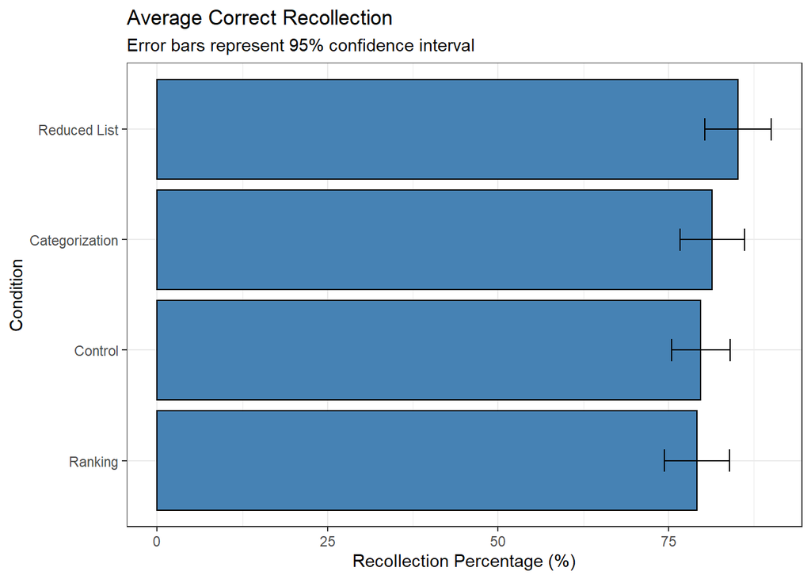

Figure 1: Bar plot of average correct recollection across conditions.

Participants in the reduced list have the greatest correct recollection (proportionally) across conditions. However, this finding is not statistically significant and is not necessarily novel considering these subjects are presented with less benefits they have to remember.

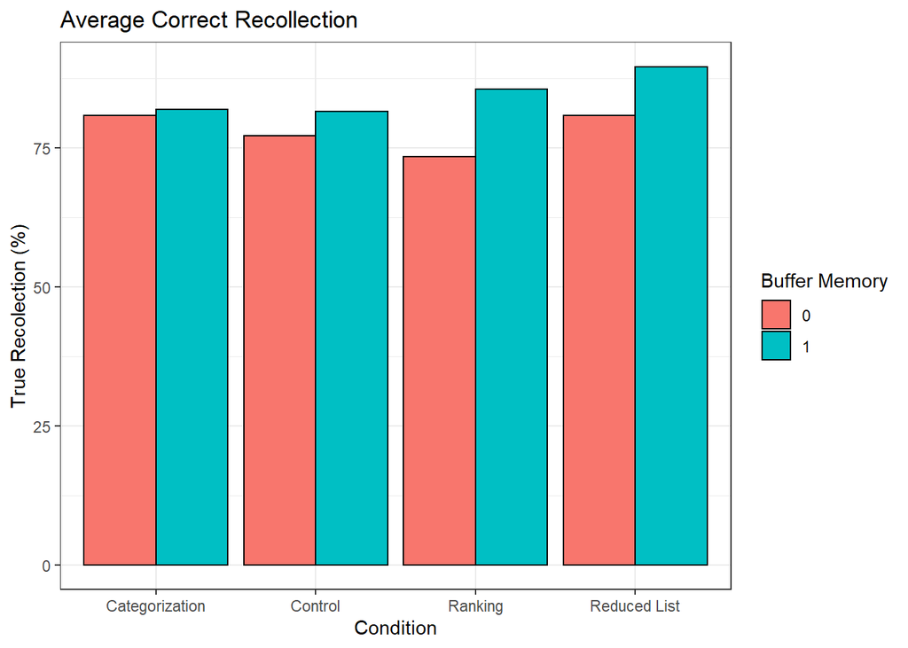

Figure 2: Average correct recollection across conditions and grouped by buffer activity performance.

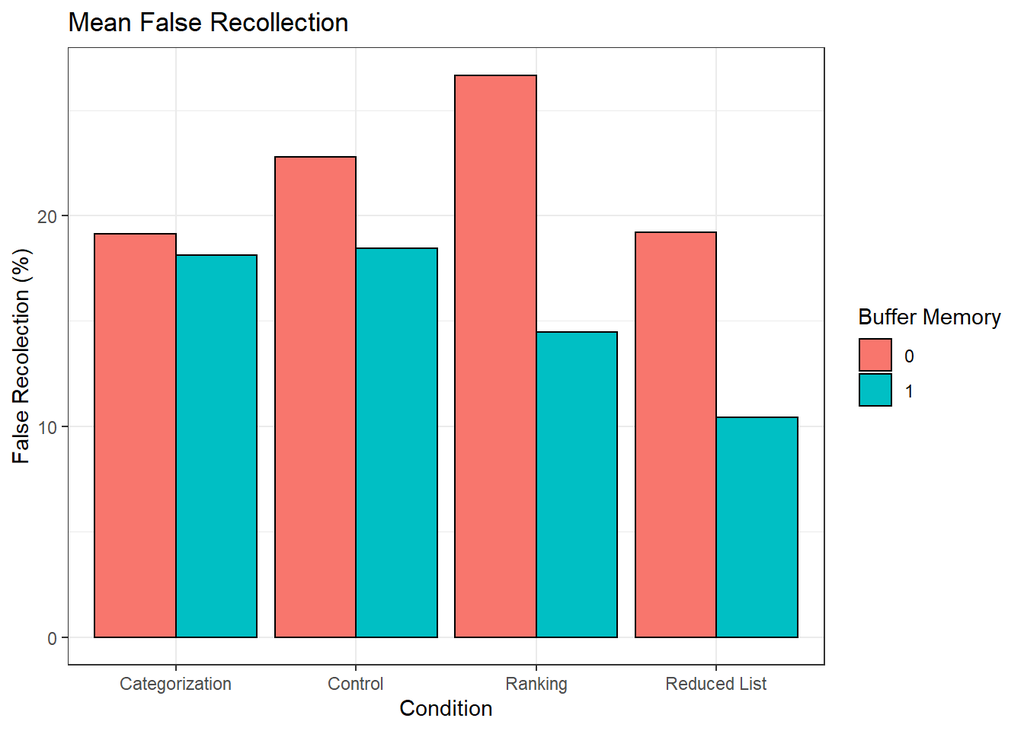

Figure 3: Average incorrect recollection across conditions and grouped by buffer activity performance.

Subjects are grouped whether they are above or below the median memory performance on the buffer activity in figures 2 and 3.

Individuals performing below the median in the buffer test appear to have systemically higher false recollection than individuals performing above the median.

These findings are relevant because they demonstrate that subjects with inherently better memory, determined by their buffer activity performance, have better recollection across all subject groups and vice versa.

### Timing

EDA of the amount of time subjects are spending looking at the emails in each of the 4 conditions.

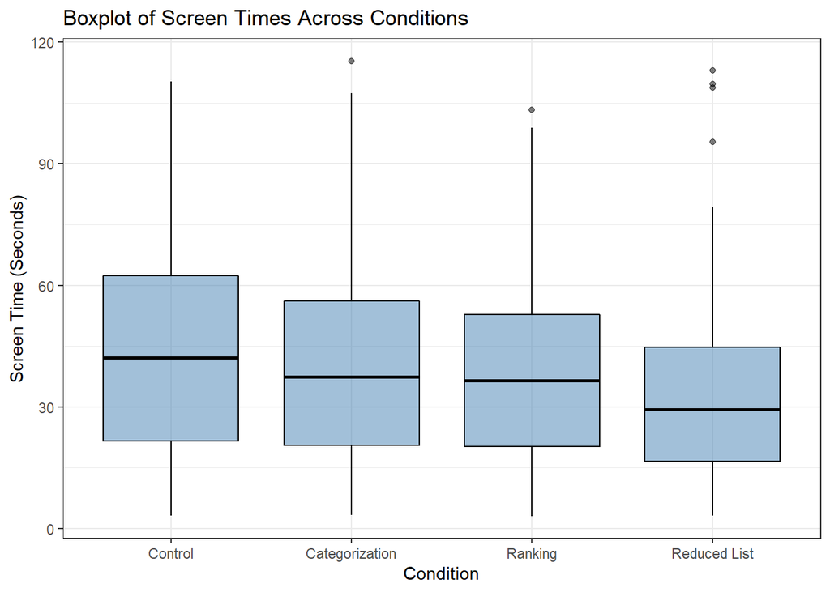

Figure 4: Boxplot of email screen time across conditions.

Screen time is not significantly different among the treatments and control but the reduced list email condition has the lowest average time spent on screen. This does not come as a surprise considering it contains 6 fewer benefits than the other conditions.

Also the control appears to have the highest screen time which may be attributed to its lack of clarity in displaying the benefits and its bulky text requesting season ticket renewals.

### Memory Score

EDA of memory score which is defined as the difference between correct and false benefit recollection. For instance, a subject that remembers 6 benefits correctly and 5 incorrectly will have a memory score of 1 (i.e., 6 - 5 = 1).

$Memory \space score = \# \space correct \space responses - \# \space incorrect \space responses$

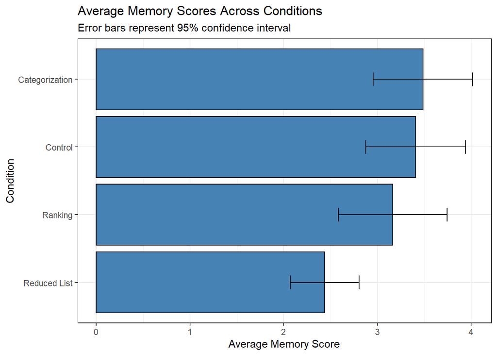

Figure 5: Bar plot of average memory score across conditions.

Across groups there is no significant difference in memory scores (not including the reduced list condition).

Note that the reduced list condition has a smaller memory score because it presents subjects with fewer benefits. This reduced choice set sets a smaller cap of their memory score relative to the other conditions.

### Renewal Likelihood

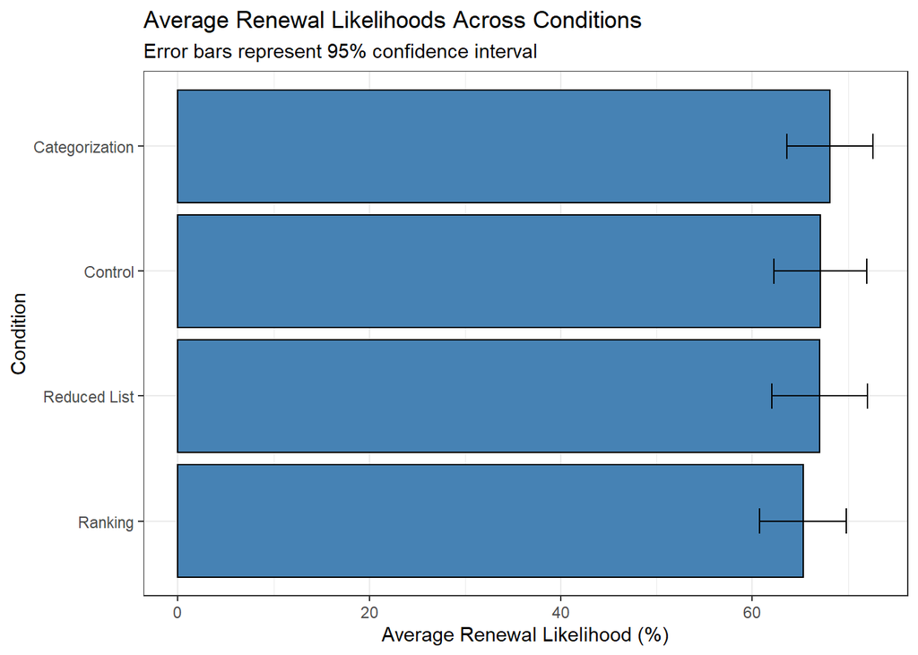

Figure 6: Average renewal likelihoods across conditions.

Although subjects in the categorization condition had the highest renewal likelihood, there is no statistically significant difference in renewal likelihoods across the conditions.

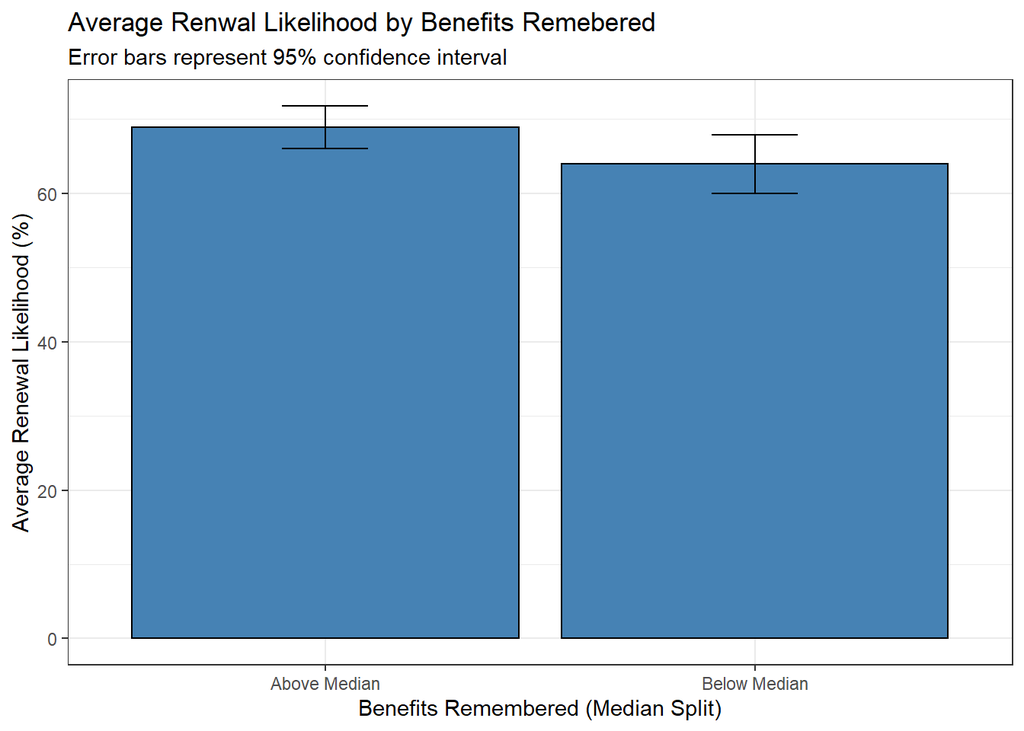

Figure 7: Average renewal likelihood grouped by median benefits remembered.

The top performing half (50%) of subjects in memory tend to have a larger renewal likelihood than the bottom half. This suggests that there may be a positive relationship between memory retention and renewal likelihoods that should be explored in the modeling section via regression analysis.

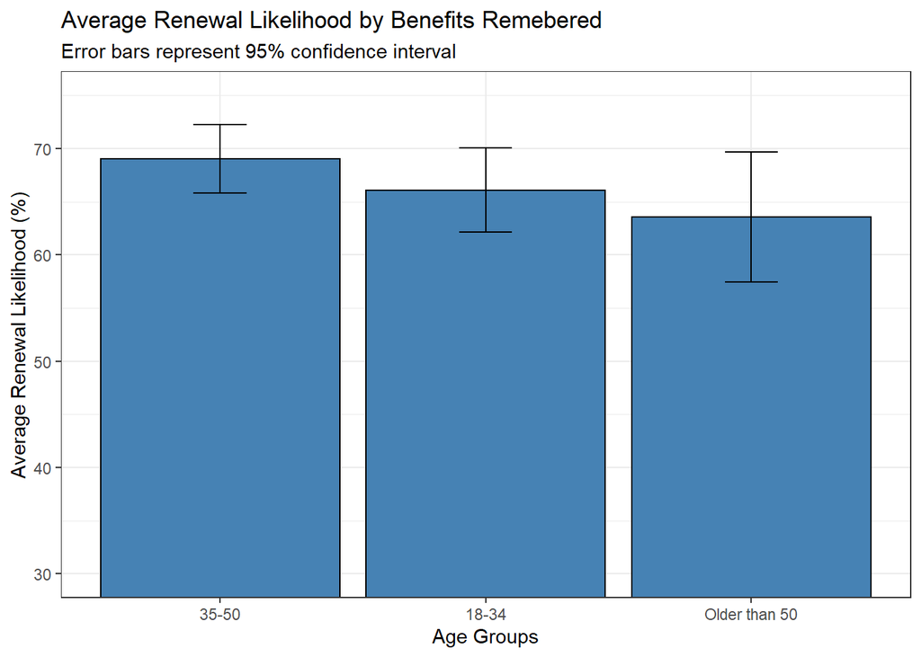

Figure 8: Average Renewal Likelihood grouped by age.

Subjects between 35-50 years appear to have a higher renewal likelihoods than other age groups. Although these differences do not appear to be statistically significant, they are worth exploring in the modeling section of the analysis.

## Statistical Tests

### Analysis of Variance (ANOVA)

#### Memory Score

Analysis of season ticket benefit retention across treatment conditions.

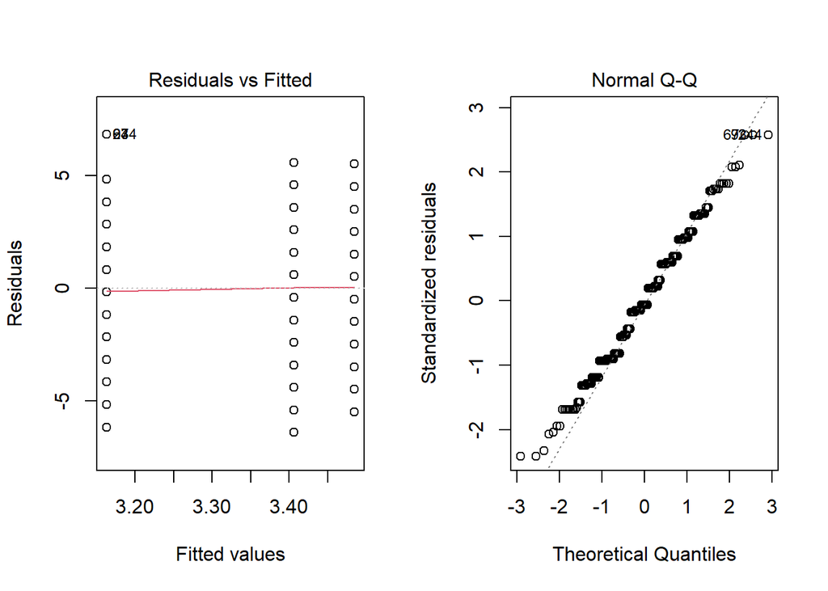

Figure 9: Scatterplot of residuals and fitted values & QQ plot to test constant variance and normality assumptions for the ANOVA model.

There is a violation of normality with the standard ANOVA testing with deviations at the tail of the diagnol in the QQ plot. So we must conduct specialty ANOVA tests that don’t require this condition.

| Linear Hypotheses | Estimate | Std.Error | P.Value |
| --- | --- | --- | --- |
| Categorization - Control = 0 | 0.078 | 0.361 | 0.993 |
| Ranking - Control = 0 | -0.244 | 0.366 | 0.843 |
| Reduced List - Control = 0 | -0.970 | 0.364 | 0.022 |

Table 3: Dunnett linear hypotheses summary table.

The specialty ANOVA test (Dunnett) suggests that there is a significant difference in memory scores between the control and reduced list. However, this finding is not meaningful considering that the reduced choice list in the treatment systemically reduces its memory score.

#### Renewal Likelihood

Analysis of mean likelihood of season ticket renewals across treatment conditions.

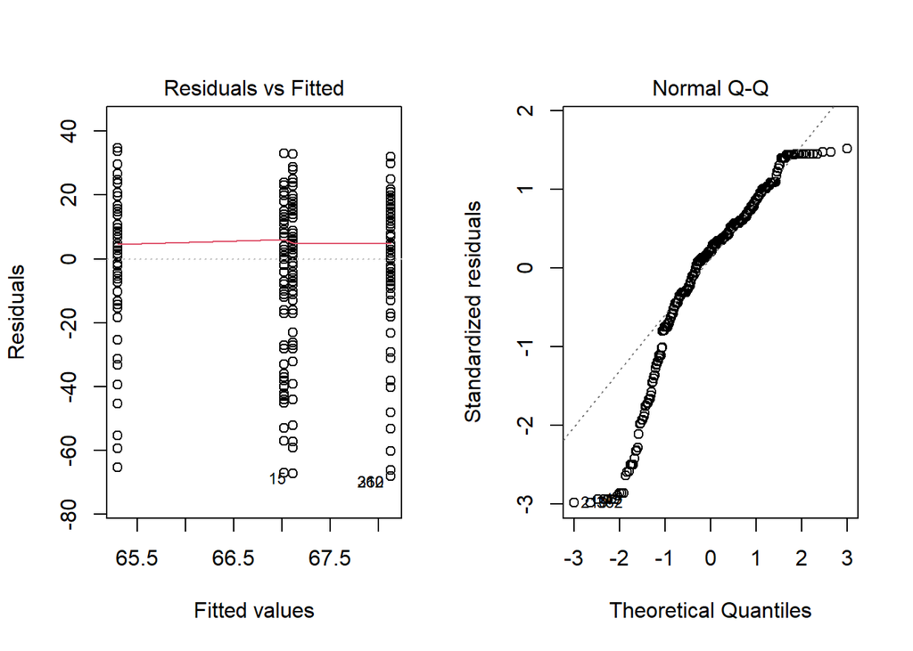

Figure 10: Scatterplot of residuals and fitted values & QQ plot to test constant variance and normality assumptions for the ANOVA model.

There is a clear violation of normality with strong deviations from the diagnol in the QQ plot so we must use specialty ANOVA tests that don’t require this assumption.

Table 4: Pairwise comparisons across conditions using Wilcoxon rank sum test with continuity correction.

The pairwise wilcoxon rank sum test suggests that there is not a statistically significant difference in renewal likelihoods across conditions.

### Regression Model

Alternatively to an ANOVA model, we can build a regression model to control for explanatory variables that may influence the effect of memory on renewal likelihood.

The following is the linear regression model:

$Renewal\ Likelihood^2 = \beta_0 +\ \beta_1\ memory\ score + \beta_2\ age\ bucket\ [35-50] + \beta_3\ age\ bucket\ [>50]$

|  | Renewal Liklihood^2 |  |  |  |
| --- | --- | --- | --- | --- |
| Predictors | Estimates | std. Error | Statistic | p |
| (Intercept) | 4660.34 | 261.80 | 17.80 | **<0.001** |
| Memory Score | 90.27 | 53.97 | 1.67 | 0.095 |
| Age Bucket (35-50) | 255.81 | 297.46 | 0.86 | 0.390 |
| Age Bucket (>50) | -296.69 | 377.31 | -0.79 | 0.432 |
| Observations | 374 |  |  |  |
| R<sup>2</sup> / R<sup>2</sup> adjusted | 0.013 / 0.005 |  |  |  |

Table 5: Linear regression summary results.

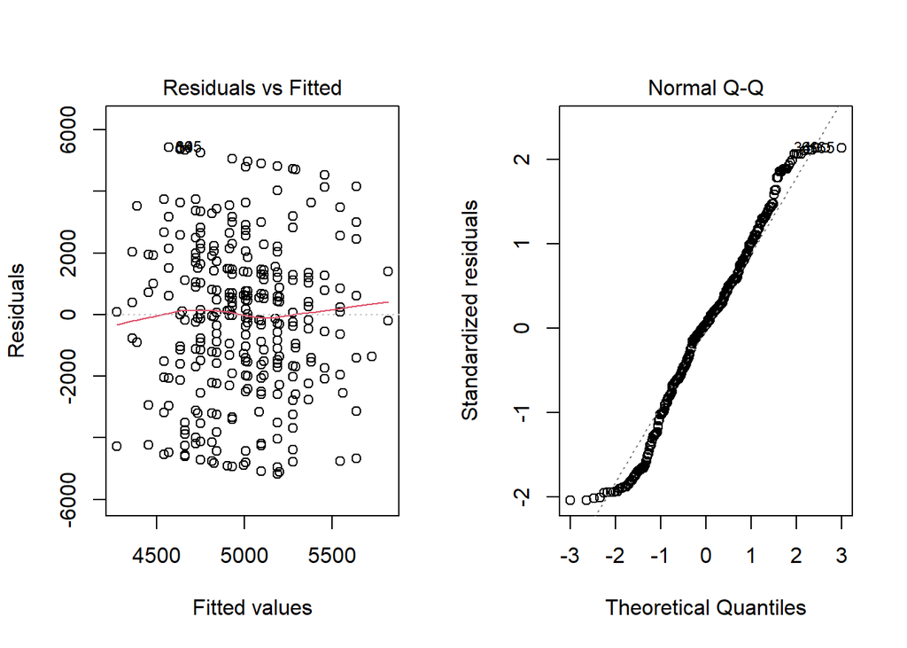

Figure 11: Scatterplot of residuals and fitted values & QQ plot to test constant variance and normality assumptions for the linear regression model.

OLS Assumptions hold and there is a statistically significant relationship (at the 10% level) between benefit memory retention and squared renewal likelihood when controlling for age groups.

**Limitations**

1. The study is limited to the online environment of general sports fans (not season ticket holders let alone hockey season ticket holders). Therefore, our subject pool is not entirely representative of the NHL season ticket holder population.
2. Given that our subjects were not guaranteed hockey fans, they may have struggled to understand some of the benefits offered and this gap in understanding could have impacted their benefit recollection.

**Main Findings**